# 1. Load the dataset

# Kurtosis' analysis takeaways

1. Almost all variables showed a negative delta kurtosis, except for Seconds of Use. This suggests that the outlier removal was effective in reducing extreme values.
2. The largest drop was observed in the Distinct Called Numbers variable, with a 125% reduction. The resulting negative kurtosis indicates very few remaining outliers (as seen in the boxplot in item 7.2).
3. However, three variables still showed high kurtosis values even after outlier removal. This explains the large number of outliers that were still visible in their boxplots, despite the data amputation:
- Seconds of Use (kurtosis = 1.94)
- Frequency of SMS (kurtosis = 1.68)
- Customer Value (kurtosis = 0.97)

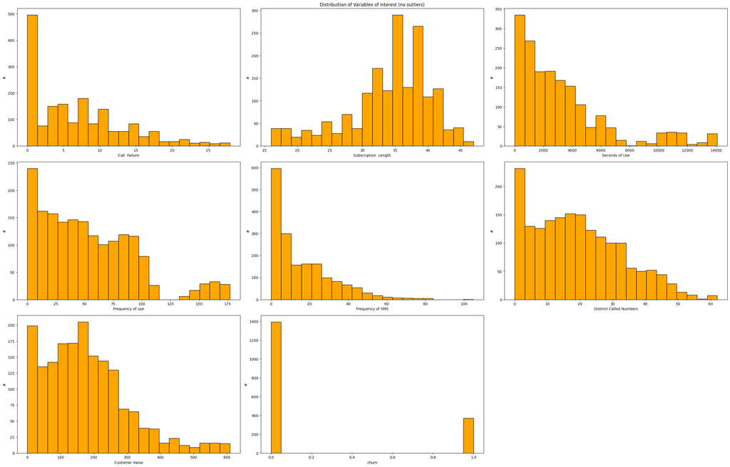

```python
plt.figure(figsize=(28,18))
plt.axis('off')
plt.title('Distribuition of Variables of interest (no outliers)')
count = 0
for i in filtered_data:
    count +=1
    plt.subplot(3, 3, count)
    plt.hist(filtered_data[i], bins = 20, color='orange', edgecolor='black')
    plt.xlabel(i)
    plt.ylabel('#')
plt.tight_layout()
plt.show()
```

```python
filtered_data.describe().T
```

|  | count | mean | std | min | 25% | 50% | 75% | max |
| --- | --- | --- | --- | --- | --- | --- | --- | --- |
| Call Failure | 1768.0 | 6.878394 | 6.439077 | 0.0 | 1.000 | 6.0 | 11.00000 | 28.0 |
| Subscription Length | 1768.0 | 34.097851 | 6.426110 | 16.0 | 31.000 | 35.0 | 38.00000 | 47.0 |
| Seconds of Use | 1768.0 | 3311.803167 | 3205.758822 | 0.0 | 957.250 | 2474.0 | 4325.00000 | 14078.0 |
| Frequency of use | 1768.0 | 53.548643 | 41.624781 | 0.0 | 20.000 | 47.0 | 81.00000 | 177.0 |
| Frequency of SMS | 1768.0 | 15.433258 | 16.328721 | 0.0 | 0.000 | 10.0 | 24.00000 | 105.0 |
| Distinct Called Numbers | 1768.0 | 19.211538 | 13.403724 | 0.0 | 8.000 | 18.0 | 28.00000 | 62.0 |
| Customer Value | 1768.0 | 177.378074 | 126.585521 | 0.0 | 82.655 | 161.0 | 244.54125 | 609.2 |
| churn | 1768.0 | 0.210973 | 0.408115 | 0.0 | 0.000 | 0.0 | 0.00000 | 1.0 |

## Main Takeaways

1. Users experienced, on average, 7 call failures.
2. The average loyalty time is 34 months.
3. The average usage time is 3,311 seconds (almost one hour).
4. On average, users use the company's service 54 times per month.
5. The average number of text messages sent is 15.
6. On average, users dial 19 distinct numbers.
7. The average customer value is 177.37.
8. It is evident that 21.10% of customers have churned.